# Modelización predictiva

César Alcívar

14/12/2021

```r
if(!require("tidyverse")) install.packages("tidyverse")
library(tidyverse)
```

# Introducción

En esta actividad se usará el fichero de datos (dat_Air) que contiene información sobre diferentes parámetros sobre la calidad del aire de una determinada ciudad europea en el año 2021. Estos datos han sido medidos en tiempo real en diferentes estaciones distribuidas en distintas zonas. Para nuestro estudio se ha seleccionado los datos recopilados de este año por una de las estaciones móviles. Se muestran las medidas de una serie de variables, tanto meteorológicas como de los principales contaminantes del aire (gases y partículas).

Todas ellas contribuyen para determinar el Índice de Calidad del Aire (ICA).

Las variables del fichero de datos son:

- Estacion: Estación móvil.
- Latitud: Latitud del lugar de medición.
- Longitud: Longitud del lugar de medición.
- Fecha: Fecha de medición.
- Periodo: Mediciones cada hora. Periodo de 1 a 24 horas (diarias).
- SO2: Concentración de SO2 (dióxido de azfre) en 𝜇𝑔/𝑚3
- H2S: Concentración de H2s (ácido sulfhidrico) en 𝜇𝑔/𝑚3
- NO: Concentración de NO (óxido nítrico) en 𝜇𝑔/𝑚3
- NO2: Concentración de (dióxido de nitrógeno) en 𝜇𝑔/𝑚3
- NOX: Concentración de NOX (óxidos de nitrógeno) en 𝜇𝑔/𝑚3
- O3: Concentración de Ozono en 𝜇𝑔/𝑚3
- PM10: Partículas en suspension <10 en 𝜇𝑔/𝑚3
- PM25: Partíulas en Suspension PM 2,5 en 𝜇𝑔/𝑚3
- BEN: Concentración de benceno en 𝜇𝑔/𝑚3
- TOL: Tolueno en 𝜇𝑔/𝑚3
- MXIL: MXileno en 𝜇𝑔/𝑚3
- Dir_Aire: Dirección del viento en grados.
- Vel: Velocidad del viento en 𝑚/𝑠𝑔.
- Tmp: Temperatura en grados centígrados.
- HR: Humedad relativa en % de hr.
- PRB: Presión Atmosférica en 𝑚𝑏.
- RS: Radiación Solar 𝑊/𝑚2
- LL: Precipitación en 𝑙/𝑚2

# Regresión lineal

La calidad del aire ha sufrido cambios que afectan a nuestro modo de vida, por lo que resulta necesario estudiarlo. Para ello se toman medidas de la emisión de diferentes contaminantes y de factores meteorológicos como por ejemplo el viento, la precipitación, radiación solar o la temperatura, con el fin de buscar relaciones entre dichas variables.

En este estudio se quiere demostrar la existencia de relación lineal entre los contaminantes atmosféricos y las variables meteorológicas.

A continuación, se carga el dataset:

```r
# Se carga el dataset
df <- read_csv("../R/data/dat_Air.csv")
summary(df)
```

```
##     Estacion     latitud         longitud         Fecha
##  Min.   :12   Min.   :43.52   Min.   :-5.691   Length:7464
##  1st Qu.:12   1st Qu.:43.52   1st Qu.:-5.691   Class :character
##  Median :12   Median :43.52   Median :-5.691   Mode  :character
##  Mean   :12   Mean   :43.52   Mean   :-5.691
##  3rd Qu.:12   3rd Qu.:43.52   3rd Qu.:-5.691
##  Max.   :12   Max.   :43.52   Max.   :-5.691
##
##     Periodo           SO2               H2S               NO
##  Min.   : 1.00   Min.   :  1.000   Min.   : 0.800   Min.   :  1.00
##  1st Qu.: 6.75   1st Qu.:  2.000   1st Qu.: 1.000   1st Qu.:  1.00
##  Median :12.50   Median :  3.000   Median : 2.000   Median :  1.00
##  Mean   :12.50   Mean   :  4.804   Mean   : 2.526   Mean   :  4.14
##  3rd Qu.:18.25   3rd Qu.:  6.000   3rd Qu.: 3.400   3rd Qu.:  3.00
##  Max.   :24.00   Max.   :105.000   Max.   :33.000   Max.   :111.00
##                  NA's   :54        NA's   :50       NA's   :63
##       NO2             NOX               O3            PM10
##  Min.   : 2.00   Min.   :  2.00   Min.   : 1.0   Min.   :  0.00
##  1st Qu.: 5.00   1st Qu.:  5.00   1st Qu.:20.0   1st Qu.: 15.00
##  Median :10.00   Median : 11.00   Median :47.0   Median : 24.00
##  Mean   :12.96   Mean   : 18.29   Mean   :42.2   Mean   : 42.83
##  3rd Qu.:18.00   3rd Qu.: 23.00   3rd Qu.:61.0   3rd Qu.: 45.00
##  Max.   :68.00   Max.   :221.00   Max.   :98.0   Max.   :724.00
##  NA's   :63      NA's   :52       NA's   :62     NA's   :43
##       PM25            BEN               TOL               MXIL
##  Min.   : 0.00   Min.   : 0.1000   Min.   :  0.100   Min.   : 0.100
##  1st Qu.: 7.00   1st Qu.: 0.1000   1st Qu.:  0.200   1st Qu.: 0.400
##  Median :11.00   Median : 0.2000   Median :  0.500   Median : 0.900
##  Mean   :12.88   Mean   : 0.6108   Mean   :  1.883   Mean   : 1.935
##  3rd Qu.:16.00   3rd Qu.: 0.5000   3rd Qu.:  1.400   3rd Qu.: 2.000
##  Max.   :96.00   Max.   :21.8000   Max.   :160.300   Max.   :53.600
##  NA's   :142     NA's   :88        NA's   :86        NA's   :86
##     Dir_Aire          Vel             Tmp              HR
##  Min.   :  1.0   Min.   :0.730   Min.   : 1.10   Min.   : 30.00
##  1st Qu.: 73.0   1st Qu.:1.000   1st Qu.:11.70   1st Qu.: 81.00
##  Median :215.0   Median :1.650   Median :15.20   Median : 92.00
##  Mean   :181.8   Mean   :2.409   Mean   :14.69   Mean   : 88.03
##  3rd Qu.:268.0   3rd Qu.:3.530   3rd Qu.:18.20   3rd Qu.: 99.00
##  Max.   :360.0   Max.   :9.760   Max.   :26.40   Max.   :100.00
##
##       PRB             RS              LL
##  Min.   : 991   Min.   : 24.0   Min.   : 0.00000
##  1st Qu.:1012   1st Qu.: 37.0   1st Qu.: 0.00000
##  Median :1016   Median : 46.0   Median : 0.00000
##  Mean   :1016   Mean   :133.5   Mean   : 0.08355
##  3rd Qu.:1020   3rd Qu.:184.0   3rd Qu.: 0.00000
##  Max.   :1031   Max.   :689.0   Max.   :13.00000
##
```

## Estudio de correlación lineal

A continuación, se calcula la matriz de correlación entre las siguientes contaminantes: O3, NO2 y PM10, junto con las variables meteorológicas: Tmp, HR, RS, Vel y Dir.

```r
cor(x = df[, c('O3', 'NO2', 'PM10')], y = df[, c('Tmp', 'HR', 'RS', 'Vel', 'Dir_Aire')], method = "pearson", use="pairwise.complete.obs")
```

```
##             Tmp         HR         RS        Vel   Dir_Aire
## O3    0.3800740 -0.4035054  0.3707692  0.5190711 -0.4192682
## NO2  -0.3607421  0.0775519 -0.1382202 -0.3443265  0.1513199
## PM10 -0.2675121  0.1096374 -0.1813403 -0.2531266  0.2015890
```

1. ¿Cual de los contaminantes atmosféricos citados anteriormente, tienen una mayor relación lineal con la RS?

Partiendo del hecho, de que se considera una relación lineal es débil si 0 < | $r$ | < 0.5; fuerte si 0,8 < | $r$ | < 1, y moderada si tiene otro valor. Siendo $r$ el coeficiente de correlación.

Examinando los valores de RS, se observa relaciones lineales débiles entre las variables. Sin embargo, existe una relación moderada entre la variable Vel y O3, con un índice de correlación de 0.52.

2. ¿Existe alguna diferencia en la relación entre las nuevas variables construídas con los valores medios diarios, con respecto a los resultados obtenidos anteriormente?

Primero, se agrupa el dataset por la Fecha.

```r
df_group <- df %>% group_by(Fecha)
df_group <- df_group %>% summarise(O3 = mean(O3, na.rm = TRUE),
                       NO2 = mean(NO2, na.rm = TRUE),
                       PM10 = mean(PM10, na.rm = TRUE),
                       Tmp = mean(Tmp, na.rm = TRUE),
                       HR = mean(HR, na.rm = TRUE),
                       RS = mean(RS, na.rm = TRUE),
                       Vel = mean(Vel, na.rm = TRUE),
                       Dir_Aire = mean(Dir_Aire, na.rm = TRUE))

head(df_group)
```

```
## # A tibble: 6 x 9
##   Fecha        O3   NO2  PM10   Tmp    HR    RS   Vel Dir_Aire
##   <chr>     <dbl> <dbl> <dbl> <dbl> <dbl> <dbl> <dbl>    <dbl>
## 1 1/1/2021  51.2  10.2   28.7  5.69  91.4  57.6  2.61    260.
## 2 1/10/2021 56.3   8.04  27.8  7.69  74.7  60.0  4.03     88.2
## 3 1/11/2021 21.6  27.6   85.6  6.73  81.2  75.6  1.38    219.
## 4 1/12/2021 19.5  34.2   68.1  5.48  82.8  80.1  2.49    257.
## 5 1/13/2021 19.8  30.8   90.5  6.30  83.8  81.9  2.44    237.
## 6 1/14/2021  8.42 37.1   80.0  6.88  91.3  60.1  2.74    257.
```

Se obtienen los índices de correlación del promedio de las siguientes variables:

```r
cor(x = df_group[, c('O3', 'NO2', 'PM10')], y = df_group[, c('Tmp', 'HR', 'RS', 'Vel', 'Dir_Aire')])
```

```
##             Tmp         HR         RS        Vel    Dir_Aire
## O3    0.2158095 -0.1299645  0.3289672  0.4769167 -0.34053142
## NO2  -0.4380055 -0.1244766 -0.3971749 -0.4255556  0.21978832
## PM10 -0.1789761 -0.2229199 -0.1014033 -0.2224160  0.07543908
```

## Modelo de regresión lineal

Se quiere explicar el nivel de ozono en función de la radiación solar.

*a) Estimar por mínimos cuadrados ordinarios un modelo lineal que explique la variable O3 en función de la radiación solar (RS). Se evaluará la bondad del ajuste, a partir del coeficiente de determinación.*

Antes de comenzar con el desarrollo del modelo, se eliminarán los valores nulos de las variables O3 y RS, y se los establecerá en un nuevo dataframe.

```r
vars <- c("O3", "RS")
df.test <- df %>% drop_na(any_of(vars))
```

A continuación se aplica el modelo de regresión lineal simple de la variable O3 en función de RS.

```r
lm.test <- lm(formula = O3 ~ RS, data = df.test)
lm.test
```

```
##
## Call:
## lm(formula = O3 ~ RS, data = df.test)
##
## Coefficients:
## (Intercept)           RS
##    34.36562      0.05911
```

Una vez que se obtuvieron los valores de $\alpha$ y $\beta$, la función resultante es la siguiente:

$$Ozono = 34.365 + 0.0591 \cdot {Radiación~Solar}$$

A continuación, se muestra en una gráfica la recta de la ecuación anterior:

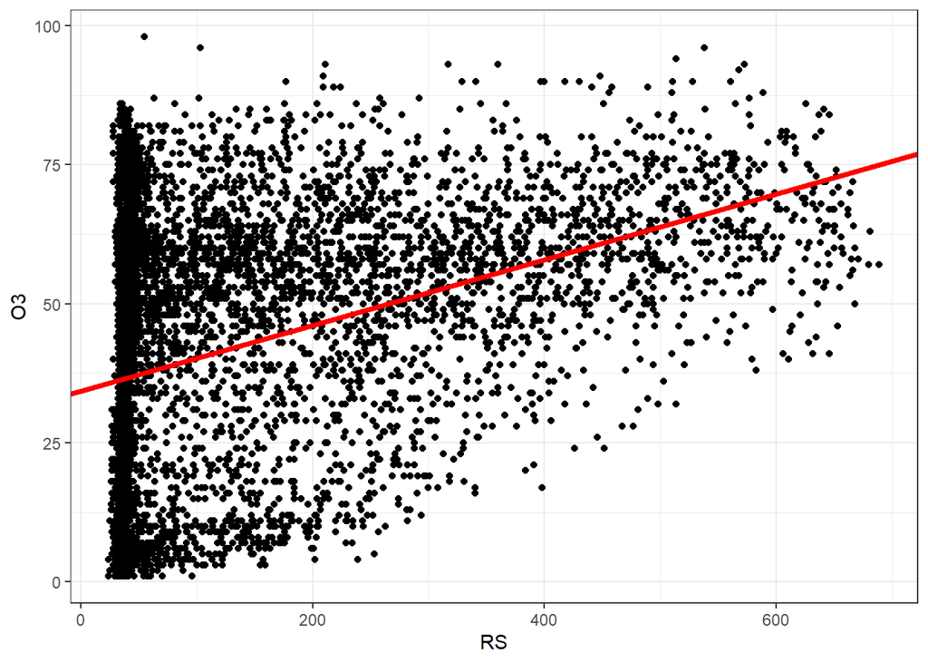

```r
a = lm.test$coefficients[1]
b = lm.test$coefficients[2]

ggplot(df.test, aes(RS, O3)) + geom_point() +
  geom_abline(aes(intercept=a,slope=b), color="red", size = 1.5) +
  theme_bw()
```

En las regresiones lineales simples tenemos que $R^2 = r^2$, entonces para calcular el coeficiente de determinación $R^2$ se obtendrá la potencia 2 del coeficiente de correlación $r$, como se muestra a continuación:

```r
r_2 <- cor(df.test$RS,df.test$O3)^2
r_2
```

```
## [1] 0.1374698
```

El valor de $R^2$ es de 0.137, esto indica que el modelo de regresión sólo nos explica un 13% de la variabilidad total de las observaciones.

*b) Para calcular el índice de calidad del aire, se establecen diferentes categorías, según sea la concentración de cada contaminante.*

El rango de valores para categorizar la variable PM10 es la siguiente:

- Muy buena: valores de (0 a 40],
- Buena: valores de (40 a 60],
- Mejorable: valores de (60 a 120],
- Mala: valores de (120 a 160],
- Muy mala: valores de (160 a 724]

A continuación, se crea la función `PM10_Category`, para categorizar los valores de la variable PM10.

```r
PM10_Category <- function(val){
  if(is.na(val)){
    return(NA)
  }
  if(val<=40){
    return("Muy buena")
  } else if(val>40 && val<=60){
    return("Buena")
  }else if(val > 60 && val<=120){
    return("Mejorable")
  }else if(val > 120 && val <= 160){
    return("Mala")
  }else if(val > 160 && val <= 724){
    return("Muy mala")
  }
}
```

Transformamos los datos PM10.

```r
PM10_cat <- factor(apply(as.array(df$PM10), MARGIN = 1, FUN = PM10_Category))
df <- cbind(df,PM10_cat)
summary(df$PM10_cat)
```

```
##     Buena      Mala Mejorable Muy buena  Muy mala      NA's
##       683       244       835      5369       290        43
```

Eliminamos los datos nulos de las variables PM10_cat y O3.

```r
vars <- c("PM10_cat", "O3")
df.test <- df %>% drop_na(any_of(vars))
```

Aplicamos el modelo.

```r
lm.test <- lm(formula = PM10_cat ~ O3, data = df.test)
lm.test
```

```
##
## Call:
## lm(formula = PM10_cat ~ O3, data = df.test)
##
## Coefficients:
## (Intercept)           O3
##     3.01971      0.01339
```

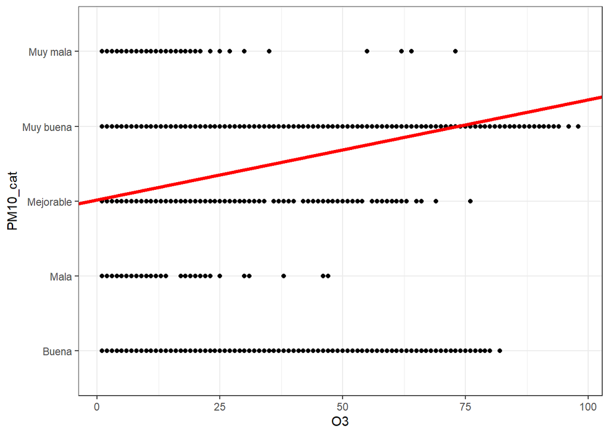

```r
a = lm.test$coefficients[1]
b = lm.test$coefficients[2]

ggplot(df.test, aes(O3, PM10_cat)) + geom_point() +
  geom_abline(aes(intercept=a,slope=b), color="red", size = 1.5) +
  theme_bw()
```

El modelo de regresión lineal no predijo correctamente los datos cuando se trató de una variable categórica.

## Modelo de regresión lineal múltiple

Se quiere explicar el nivel de ozono en función de la radiación solar (RS),concentración de dióxido de nitrógeno (NO2), temperatura (Tmp) y dirección del aire (Dir_Aire).

*a) Primero, se añadirá al modelo del apartado a), la variable explicativa (Dir_Aire).¿El modelo ha mejorado?*

Se eliminan los elementos nulos de las variables “O3”, “RS” y “Dir_Aire”.

```r
vars <- c("O3", "RS", "Dir_Aire")
df.test <- df %>% drop_na(any_of(vars))
```

Se aplica la regresión lineal múltiple.

```r
lm.test = lm(formula = O3 ~ RS+Dir_Aire, data = df.test)
lm.test
```

```
##
## Call:
## lm(formula = O3 ~ RS + Dir_Aire, data = df.test)
##
## Coefficients:
## (Intercept)           RS     Dir_Aire
##    51.05399      0.04390     -0.08069
```

La función resultante es la siguiente:

$$Ozono = 51.05399 + 0.04390 \cdot {Radiación~Solar} - 0.08069 \cdot {Dirección~del~viento}$$

Para calcular el coeficiente de determinación de una regresión lineal múltiple, se utiliza una de las siguientes formulas:

$$R^2 = \frac{SCR}{SCT} ~~~~~~ R^2 = 1 - \frac{SCE}{SCT} ~~~~~~ 0\leq R^2 \leq 1$$

```r
df.test$O3_hat = 51.05399 + 0.04390 * df.test$RS - 0.08069 * df.test$Dir_Aire
SCT = sum((df.test$O3 - mean(df.test$O3))^2)
SCE = sum((df.test$O3 - df.test$O3_hat)^2)
R_2 = 1 - (SCE/SCT)
R_2
```

```
## [1] 0.2457143
```

```r
SCR = sum((df.test$O3_hat -  mean(df.test$O3))^2)
# Se verifica que el valor de R_2 sea correcto
assertthat::are_equal(round(SCR/SCT,3), round(R_2,3))
```

```
## [1] TRUE
```

Comprando los resultados se tiene:

$$Ozono = 34.365 + 0.0591 \cdot {Radiación~Solar} ~~~~~~ R^2 = 0.137 \\
Ozono = 51.05399 + 0.04390 \cdot {Radiación~Solar} - 0.08069 \cdot {Dirección~del~viento} ~~~~~~ R^2 = 0.245$$
Cuando el ozono está en función de la radiación solar y la dirección del viento, el modelo mejora aproximadamente el doble con respecto al modelo a), con un valor de $R^2$ de 0.245. Esto indica que el modelo de regresión sólo nos explica un 24.5% de la variabilidad total de las observaciones.

*b) Posteriormente se añade al modelo anterior la variable (NO2). ¿Existe una mejora del modelo?*

Se eliminan los elementos nulos de las variables “O3”, “RS”, “Dir_Aire” y “NO2”.

```r
vars <- c("O3", "RS", "Dir_Aire", "NO2")
df.test <- df %>% drop_na(any_of(vars))
```

Se aplica la regresión lineal múltiple.

```r
lm.test_b = lm(formula = O3 ~ RS+Dir_Aire+NO2, data = df.test)
lm.test_b
```

```
##
## Call:
## lm(formula = O3 ~ RS + Dir_Aire + NO2, data = df.test)
##
## Coefficients:
## (Intercept)           RS     Dir_Aire          NO2
##    67.86309      0.03414     -0.06374     -1.43514
```

```r
df.test$O3_hat = 67.86309 + 0.03414 * df.test$RS -0.06374 * df.test$Dir_Aire - 1.43514 * df.test$NO2
SCT = sum((df.test$O3 - mean(df.test$O3))^2)
SCE = sum((df.test$O3 - df.test$O3_hat)^2)
R_2 = 1 - (SCE/SCT)
R_2
```

```
## [1] 0.5805328
```

Cuando el ozono está en función de la radiación solar, la dirección del viento y Concentración de (dióxido de nitrógeno) el modelo mejora aproximadamente el doble con respecto al modelo anterior. El valor de $R^2$ de 0.58. Esto indica que el modelo de regresión sólo nos explica un 58.0% de la variabilidad total de las observaciones.

*c) Se toma la variable (Tmp) y se añade al modelo anterior. Se pide comprobar la presencia o no decolinealidad entre las variables (RS) y (Tmp)*

Antes de evaluar el modelo con la variable “Tmp”, se pide comprobar la presencia de colinealidad entre las variables (RS) y (Tmp). Para esto se instaló la librería `faraway` y si utliza la función `vif`

```r
if(!require(faraway)){
    install.packages('faraway')
  library(faraway)
}
vif(df[,c("RS", "Tmp")])
```

```
##       RS      Tmp
## 1.197387 1.197387
```

Un valor de VIF mayor a 10 se considera que las variables independientes deberían ser eliminadas del modelo. Los valores de VIF encontrados son menores que el límite superior de 10. Esto indica que la variable “RS” y “Tmp” no están correlacionada entre sí.

Se eliminan los elementos nulos de las variables “O3”, “RS”, “Dir_Aire” “NO2” y “Tmp”.

```r
vars <- c("O3", "RS", "Dir_Aire", "NO2", "Tmp")
df.test <- df %>% drop_na(any_of(vars))
```

Se aplica la regresión lineal múltiple.

```r
lm.test_c = lm(formula = O3 ~ RS+Dir_Aire+NO2+Tmp, data = df.test)
lm.test_c
```

```
##
## Call:
## lm(formula = O3 ~ RS + Dir_Aire + NO2 + Tmp, data = df.test)
##
## Coefficients:
## (Intercept)           RS     Dir_Aire          NO2          Tmp
##    66.44400      0.03328     -0.06327     -1.42320      0.08813
```

```r
df.test$O3_hat = 66.44400 + 0.03328 * df.test$RS -0.06327 * df.test$Dir_Aire - 1.42320 * df.test$NO2 + 0.08813 * df.test$Tmp
SCT = sum((df.test$O3 - mean(df.test$O3))^2)
SCE = sum((df.test$O3 - df.test$O3_hat)^2)
R_2 = 1 - (SCE/SCT)
R_2
```

```
## [1] 0.5807307
```

Cuando el ozono está en función de la radiación solar, la dirección del viento, Concentración de (dióxido de nitrógeno) y Temperatura, el modelo no presenta mejora significative frente al modelo anterior.

## Diagnosis del modelo

```r
if(!require(ggfortify)){
    install.packages('ggfortify')
  library(ggfortify)
}
```

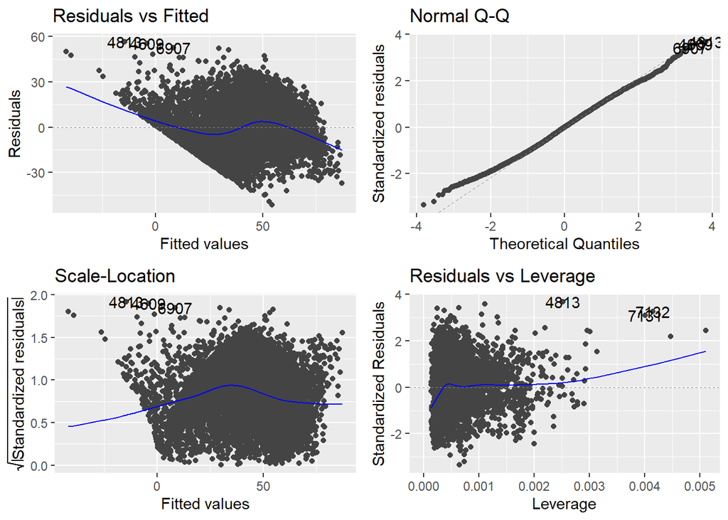

```r
autoplot(lm.test_b)
```

## Predicción del modelo

Según el modelo del apartado c), calcular la concentración de O3, si se tienen valores de RS de 180, NO2 de 15, Dir_Aire de 250 grados y Tmp de 20 grados centígrados.

Recordamos los valores del modelo.

```r
lm.test_c
```

```
##
## Call:
## lm(formula = O3 ~ RS + Dir_Aire + NO2 + Tmp, data = df.test)
##
## Coefficients:
## (Intercept)           RS     Dir_Aire          NO2          Tmp
##    66.44400      0.03328     -0.06327     -1.42320      0.08813
```

La ecuación del modelo sería:

```r
RS <- 180; NO2 <- 15; Dir_Aire <- 250; Tmp <- 20
Q3 = 66.44400 + 0.03328 * RS - 0.06327 * Dir_Aire - 1.42320 + 0.08813 * Tmp
Q3
```

```
## [1] 56.9563
```

# Regresión logística

Se quiere estudiar la concentración de O3 del aire de una determinada ciudad.

Primero se creará una nueva variable dicotómica llamada icO3 (índice de calidad del aire basado en O3). Se codificará de la siguiente manera:

- buena: valores de (0 a 80],
- mejorable: valores de (80 a 100]

```r
O3_Category <- function(val){
  if(is.na(val)){
    return(NA)
  }
  if(val <= 80){
    return("buena")
  } else if(val > 80 && val<=100) {
    return("mejorable")
  }
}

icO3 <- factor(apply(as.array(df$O3), MARGIN = 1, FUN = O3_Category))
df <- cbind(df,icO3)
summary(df$icO3)
```

```
##     buena mejorable      NA's
##      7238       164        62
```

## Estudio de relaciones entre variables. Análisis crudo de posibles factores de riesgo

*a) Se visualiza la relación entre icO3 y las variables independientes: RS, Vel y HR. Para ello se recodificaran las variables RS y Vel, dejando la variable cuantitativa HR, tal como está en la base de datos.*

A continuación, se categorizan las variable RS y Vel.

```r
RS_Category = function(val){
  if(is.na(val)){
    return(NA)
  }
  if(val <= 100){
    return("normal_baja")
  } else if(val > 100 && val <= 700){
    return("normal_alta")
  }
}

Vel_Category = function(val){
  if(is.na(val)){
    return(NA)
  }
  if(val <= 3){
    return("flojo")
  } else if(val > 3 && val <=10){
    return("moderado")
  }
}

Vel_cat2  <- factor(apply(as.array(df$Vel), MARGIN = 1, FUN = Vel_Category))
RS_cat2   <- factor(apply(as.array(df$RS), MARGIN = 1, FUN = RS_Category))

df <- cbind(df,RS_cat2)
df <- cbind(df,Vel_cat2)
```

```r
result <- table(df$icO3, df$RS_cat2)
result
```

```
##
##             normal_alta normal_baja
##   buena            2572        4666
##   mejorable         103          61
```

Se observa que, las mediciones de RS normar_alta 2572 tienen ICO3 buena frente a 103 mediciones de RS normal_alta pueden mejorar el ICO3. Con respecto a las mediciones de RS normal_baja hay 4666 con un ICO3 buena y 61 mediciones de RS normal_baja que pueden mejorar el ICO3. Si lo pasamos a porcentajes, el 96% de las mediciones de RS tienen buena ICO3 y un 4% de RS normal_alta puede mejorar.

```r
normal_alta.buena = result[1,1]/(result[1,1] + result[2,1])
normal_alta.mejorable = result[2,1]/(result[1,1] + result[2,1])
odds.normal_alta = normal_alta.mejorable/normal_alta.buena

normal_baja.buena = result[1,2]/(result[1,2] + result[2,2])
normal_baja.mejorable = result[2,2]/(result[1,2] + result[2,2])
odds.normal_baja = normal_baja.mejorable/normal_baja.buena
c(odds.normal_alta, odds.normal_baja)
```

```
## [1] 0.04004666 0.01307330
```

- Odds(normal_alta) = 0.04. Por lo tanto, de cada 100 mediciones de RS normal_alta el ICO3 es buena, 4 mediciones de RS normal_alta el ICO3 son mejorables.
- Odds(normal_baja) = 0.01. Por tanto, de cada 100 mediciones de RS normal_baja el ICO3 es buena, 1 mediciones de RS normal_baja el ICO3 son mejorables.

```r
OR_rs = odds.normal_baja/odds.normal_alta
OR_rs
```

```
## [1] 0.3264516
```

Se tiene un OR para la variable RS de 0.32, con que lo que la ocurrencia de encontrar RS nomal_baja es 0.32 veces menor que relación a RS normal_alta.

```r
result <- table(df$icO3, df$Vel_cat2)
result
```

```
##
##             flojo moderado
##   buena      5004     2234
##   mejorable    88       76
```

Se observa que, las mediciones de Vel flojo tienen ICO3 buena frente a 88 mediciones de Ven flojo pueden mejorar el ICO3. Con recpecto a las mediciones de Vel moderado hay 2234 con ICO3 buena y 76 mediciones de Vel mediciones de Vel moderado que pueden mejorar el ICO3.

```r
flojo.buena = result[1,1]/(result[1,1] + result[2,1])
flojo.mejorable = result[2,1]/(result[1,1] + result[2,1])
odds.flojo = flojo.mejorable/flojo.buena

moderado.buena = result[1,2]/(result[1,2] + result[2,2])
moderado.mejorable = result[2,2]/(result[1,2] + result[2,2])
odds.moderado = moderado.mejorable/moderado.buena
c(odds.flojo, odds.moderado)
```

```
## [1] 0.01758593 0.03401970
```

- Odds(flojo) = 0.017. Por lo tanto, de cada 100 mediciones de Vel flojo el ICO3 es buena, 1.7 mediciones de Vel flojo el ICO3 son mejorables.
- Odds(moderado) = 0.034. Por tanto, de cada 100 mediciones de Vel moderado el ICO3 es buena, 3.4 mediciones de RS moderado el ICO3 son mejorables.

```r
OR = odds.flojo / odds.moderado
OR
```

```
## [1] 0.5169338
```

## Modelo de regresión logística

*a) Estimad el modelo de regresión logística tomando como variable dependiente icO3 variable explicativa RS_cat2. Calculad la OR a partir de los resultados del modelo y su intervalo de confianza. ¿Se puede considerar que la radiación solar es un factor de riesgo?*

```r
df$icO3n = ifelse(df$icO3 == "buena", 0, 1)
model.logist1 = glm(formula = icO3n~ RS_cat2, family = binomial(link = "logit"), data = df)
summary(model.logist1)
```

```
##
## Call:
## glm(formula = icO3n ~ RS_cat2, family = binomial(link = "logit"),
##     data = df)
##
## Deviance Residuals:
##     Min       1Q   Median       3Q      Max
## -0.2802  -0.2802  -0.1612  -0.1612   2.9496
##
## Coefficients:
##                    Estimate Std. Error z value Pr(>|z|)
## (Intercept)         -3.2177     0.1005  -32.02  < 2e-16 ***
## RS_cat2normal_baja  -1.1195     0.1634   -6.85 7.36e-12 ***
## ---
## Signif. codes:  0 '***' 0.001 '**' 0.01 '*' 0.05 '.' 0.1 ' ' 1
##
## (Dispersion parameter for binomial family taken to be 1)
##
##     Null deviance: 1573.9  on 7401  degrees of freedom
## Residual deviance: 1524.8  on 7400  degrees of freedom
##   (62 observations deleted due to missingness)
## AIC: 1528.8
##
## Number of Fisher Scoring iterations: 7
```

La fórmula general del modelo de regresión logística es la siguiente:

$$P(X) = \frac{1}{1 + e^{-(\alpha + \sum \beta_iX_i)}}$$

Tomando los valores resultantes del modelo anterior, la ecuación para `icO3n~ RS_cat2` sería:

$$P(X) = \frac{1}{1 + e^{-(-3.2177 - 1.1195 ~ RS_cat2)}}$$

```r
rs_cat2_num = 0
rs_cat2_cat = "normal_alta"

rs = (exp(-3.2177) - 1.1195 * rs_cat2_num) / (1 + exp(-3.2177) - 1.1195 * rs_cat2_num)

pred<-predict(model.logist1, data.frame(RS_cat2=rs_cat2_cat),type ="response")

assertthat::are_equal(round(rs, 4), round(as.numeric(pred), 4))
```

```
## [1] TRUE
```

```r
rs
```

```
## [1] 0.03850505
```

donde:

```r
exp(coefficients(model.logist1))
```

```
##        (Intercept) RS_cat2normal_baja
##         0.04004666         0.32645163
```

```r
exp_rs =exp(c(-3.217710, -1.119473))

# Se comprueba que OR calculado en la sección anterior es igual a la que se obtiene de las funciones de R
assertthat::are_equal(round(exp_rs[2], 3), round(OR_rs, 3))
```

```
## [1] TRUE
```

```r
exp_rs
```

```
## [1] 0.04004666 0.32645179
```

```r
exp(confint(model.logist1))
```

```
##                         2.5 %     97.5 %
## (Intercept)        0.03268487 0.04848337
## RS_cat2normal_baja 0.23583375 0.44810596
```

Se tiene un OR para la variable RS normal_baja de 0.32, con que lo que la ocurrencia de encontrar ICO3 con RS nomal_baja es 0.32 veces menor, que relación a RS normal_alta.

Además, como el IC para el OR de RS es (0.235, 0.448), se puede decir que el ICO3 con RS normal_baja es entre 0.235 y 0.448 veces menos probable que RS normal_alta

**¿Se puede considerar que la radiación solar es un factor de riesgo?**

Siendo RS normal_alta más peligrosos que RS normal_baja. Si se considera un factor de riesgo la radiación solar por que la RS normal_baja es 0.32 menor en relación con RS normal_alta.

*b) Se crea un nuevo modelo con la misma variable dependiente y se añade al apartado a) la variable TMP. Interpretar si nos encontramos o no ante una posible variable de confusión.*

```r
model.logist2 = glm(formula = icO3~ RS_cat2+Tmp, family = binomial(link = "logit"), data = df)
summary(model.logist2)
```

```
##
## Call:
## glm(formula = icO3 ~ RS_cat2 + Tmp, family = binomial(link = "logit"),
##     data = df)
##
## Deviance Residuals:
##     Min       1Q   Median       3Q      Max
## -0.4442  -0.2414  -0.1835  -0.1415   3.1460
##
## Coefficients:
##                    Estimate Std. Error z value Pr(>|z|)
## (Intercept)         -5.0900     0.4195 -12.133  < 2e-16 ***
## RS_cat2normal_baja  -0.7821     0.1763  -4.435 9.19e-06 ***
## Tmp                  0.1070     0.0225   4.755 1.99e-06 ***
## ---
## Signif. codes:  0 '***' 0.001 '**' 0.01 '*' 0.05 '.' 0.1 ' ' 1
##
## (Dispersion parameter for binomial family taken to be 1)
##
##     Null deviance: 1573.9  on 7401  degrees of freedom
## Residual deviance: 1500.1  on 7399  degrees of freedom
##   (62 observations deleted due to missingness)
## AIC: 1506.1
##
## Number of Fisher Scoring iterations: 7
```

Se puede observar una diferencia significativo (-1.1195, -0.782), por lo que podemos concluir que si existe confusión.

*c) Se añade al modelo del apartado a) la variable HR. Estudiar la existencia o no de interacción entre las variables explicativas RS_cat2 y HR. Interpretar.*

```r
model.logist3 = glm(formula = icO3~ RS_cat2+HR, family = binomial(link = "logit"), data = df)
summary(model.logist3)
```

```
##
## Call:
## glm(formula = icO3 ~ RS_cat2 + HR, family = binomial(link = "logit"),
##     data = df)
##
## Deviance Residuals:
##     Min       1Q   Median       3Q      Max
## -0.4652  -0.2546  -0.1668  -0.1471   3.0175
##
## Coefficients:
##                     Estimate Std. Error z value Pr(>|z|)
## (Intercept)        -1.536791   0.447365  -3.435 0.000592 ***
## RS_cat2normal_baja -0.897468   0.173895  -5.161 2.46e-07 ***
## HR                 -0.021077   0.005591  -3.770 0.000163 ***
## ---
## Signif. codes:  0 '***' 0.001 '**' 0.01 '*' 0.05 '.' 0.1 ' ' 1
##
## (Dispersion parameter for binomial family taken to be 1)
##
##     Null deviance: 1573.9  on 7401  degrees of freedom
## Residual deviance: 1511.9  on 7399  degrees of freedom
##   (62 observations deleted due to missingness)
## AIC: 1517.9
##
## Number of Fisher Scoring iterations: 7
```

4. Se crea un nuevo modelo con las variables explicativas RS_cat2 y Dir_Aire. ¿Existe una mejora del modelo?

```r
model.logist4 = glm(formula = icO3~ RS_cat2+Dir_Aire, family = binomial(link = "logit"), data = df)
summary(model.logist4)
```

```
##
## Call:
## glm(formula = icO3 ~ RS_cat2 + Dir_Aire, family = binomial(link = "logit"),
##     data = df)
##
## Deviance Residuals:
##     Min       1Q   Median       3Q      Max
## -0.4739  -0.2547  -0.1279  -0.0943   3.5593
##
## Coefficients:
##                     Estimate Std. Error z value Pr(>|z|)
## (Intercept)        -2.119843   0.136367 -15.545  < 2e-16 ***
## RS_cat2normal_baja -0.672660   0.167669  -4.012 6.03e-05 ***
## Dir_Aire           -0.010001   0.001109  -9.017  < 2e-16 ***
## ---
## Signif. codes:  0 '***' 0.001 '**' 0.01 '*' 0.05 '.' 0.1 ' ' 1
##
## (Dispersion parameter for binomial family taken to be 1)
##
##     Null deviance: 1573.9  on 7401  degrees of freedom
## Residual deviance: 1413.3  on 7399  degrees of freedom
##   (62 observations deleted due to missingness)
## AIC: 1419.3
##
## Number of Fisher Scoring iterations: 8
```